# Reproducible Research: Peer Assessment 1

#### STEP 1 - Loading and preprocessing the data

```r
# Make sure needed packages loaded
req.pkg <- c("ggplot2","dplyr","lubridate")
pkgs.not.installed <- req.pkg[!sapply(req.pkg, function(p) require(p, character.only=T))]
if (length(pkgs.not.installed)>0) install.packages(pkgs.not.installed, dependencies=TRUE)
# load required packages
library(ggplot2)
library(dplyr)
library(lubridate)
# document session info for reference
```

```r
# create folder where the zip will be downloaded
if (!file.exists("data")) {
    dir.create("data")
}
## download and unzip file to if not already done
sourceUrl <- "http://d396qusza40orc.cloudfront.net/repdata%2Fdata%2Factivity.zip"
zipFile <- "./data/factivity.zip"  # file to be downloaded
# only download if zip file has not been downloaded before
if ( !file.exists(zipFile) ) {
    download.file(sourceUrl, zipFile)
}
# unzip the files (will do nothing if we previously did this)
filepaths <- unzip(zipFile,exdir = "./data")
# read data into data frame
activity <- read.csv("./data/activity.csv")
```

#### Step 2 - What is mean total number of steps taken per day?

Create a new summary data frame of total number of steps taken each day. Create a histogram of steps taken each day. Use this data frame to calculate the mean and median.

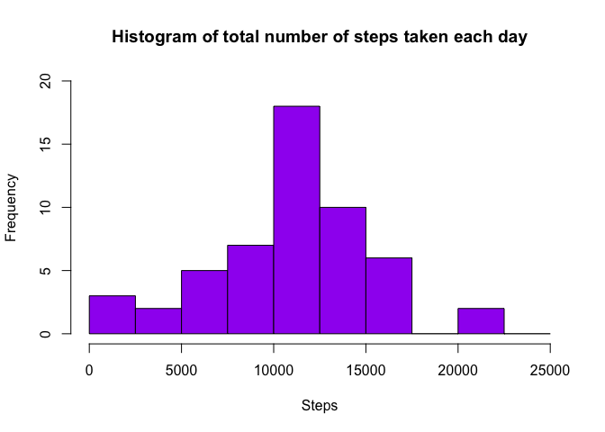

```r
# create a new data frame of total number of steps taken each day
activity_by_day <- activity %>% select (date,steps) %>%
        filter(!is.na(steps)) %>%
             group_by (date) %>%
                summarise(totalstepsperday= sum(steps))
# Make a histogram of the total number of steps taken each day
hist(activity_by_day$totalstepsperday,
     breaks=seq(0,25000,by=2500),
         ylim=c(0,20),
            col="purple",
                main="Histogram of total number of steps taken each day",
                    xlab="Steps",
                        ylab="Frequency",
                            border="black")
```

```r
# Calculate and report the mean and median total number of steps taken per day
mean(activity_by_day$totalstepsperday , na.rm = TRUE)
```

```
## [1] 10766.19
```

```r
median(activity_by_day$totalstepsperday , na.rm = TRUE)
```

```
## [1] 10765
```

```r
s2mean <- mean(activity_by_day$totalstepsperday , na.rm = TRUE)
s2median <- median(activity_by_day$totalstepsperday , na.rm = TRUE)
```

#### STEP 3 - What is the average daily activity pattern?

```r
activity_daily <- activity %>% select (interval,steps) %>%
        filter(!is.na(steps)) %>%
             group_by (interval) %>%
                summarise(meandailysteps= mean(steps))
summary (activity_daily)
```

```
##     interval      meandailysteps
##  Min.   :   0.0   Min.   :  0.000
##  1st Qu.: 588.8   1st Qu.:  2.486
##  Median :1177.5   Median : 34.113
##  Mean   :1177.5   Mean   : 37.383
##  3rd Qu.:1766.2   3rd Qu.: 52.835
##  Max.   :2355.0   Max.   :206.170
```

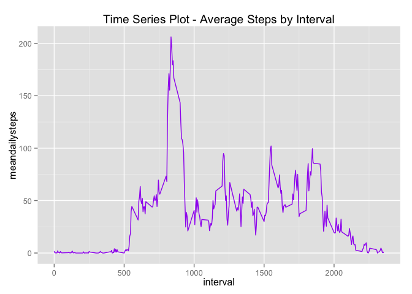

```r
p <- ggplot(activity_daily, aes(x=interval, y=meandailysteps))
p + geom_line(color="purple") +
    ggtitle("Time Series Plot - Average Steps by Interval")
```

```r
# calculate which 5-minute interval, on average across all the days in the dataset, contains the maximum number of steps?
maxstepsinterval <- activity_daily %>% slice(which.max(meandailysteps))
```

835 is the 5-minute interval that on average across contains the maximum number of steps?

#### Step 4 - Imputing missing values

To replace NA’s use the mean of steps of each 5-minute interval, create a new data frame. Add a new column of mean calculated previously using the ‘interval’ as key. Replace each NA with the mean from the new column.

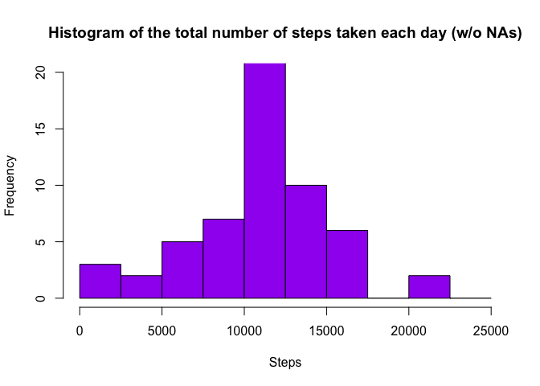

```r
# add mean daily interval column to activity df, then replace NA's with this value
activity.noNAs <- merge(activity,activity_daily,by="interval")
# round to nearest whole number
activity.noNAs$meandailysteps <- round(activity.noNAs$meandailysteps, digits = 0)
# replace NA's with mean of daily interval
activity.noNAs$steps <- ifelse(is.na(activity.noNAs$steps),activity.noNAs$meandailysteps,activity.noNAs$steps)
activity.noNAs$meandailysteps <- NULL # remove mean column, not needed
activity.noNAs_by_day <- activity.noNAs %>% select (date,steps) %>%
        filter(!is.na(steps)) %>%
             group_by (date) %>%
                summarise(totalstepsperday= sum(steps))
hist(activity.noNAs_by_day$totalstepsperday,
     breaks=seq(0,25000,by=2500),
         ylim=c(0,20),
            col="purple",
                main="Histogram of the total number of steps taken each day (w/o NAs)",
                    xlab="Steps",
                        ylab="Frequency",
                            border="black")
```

```r
# calculate mean
mean(activity.noNAs_by_day$totalstepsperday , na.rm = TRUE)
```

```
## [1] 10765.64
```

```r
# calculate mediun
median(activity.noNAs_by_day$totalstepsperday , na.rm = TRUE)
```

```
## [1] 10762
```

#### STEP 5 - Are there differences in activity patterns between weekdays and weekends?

To answer this question, flag each observation as either a ‘weekend’ or ‘weekday’. Compute the day of week when each obeservation (row) was taken. A Saturday and Sunday observation is flagged as ‘weekend’, the rest ‘weekday. Plot a separate time series graph for ’weekend’ and ‘weekday’

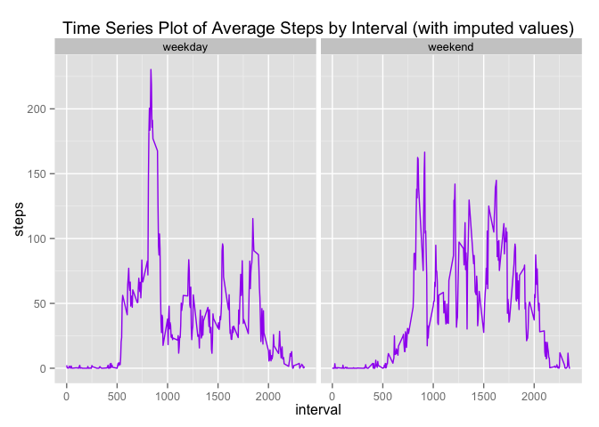

```r
# create a new factor variable with two levels – “weekday” and “weekend”
activity.noNAs$date <- as.Date(activity.noNAs$date, format = "%Y-%m-%d") # convert date
activity.noNAs$dayofweek <- weekdays(activity.noNAs$date) # compute day of week
activity.noNAs <- activity.noNAs %>% mutate(day = ifelse((dayofweek == "Sunday") | (dayofweek == "Saturday") ,"weekend","weekday")) # flag weekday or weekend
activity.noNAs$day <- as.factor(activity.noNAs$day)
activity.noNAs_daily <- activity.noNAs %>% select (interval,steps,day) %>%
        filter(!is.na(steps)) %>%
             group_by (interval,day) %>%
                summarise(meandailysteps= mean(steps))
ggplot(activity.noNAs_daily,aes(interval,meandailysteps)) +
        ggtitle("Time Series Plot of Average Steps by Interval (with imputed values)") +
            facet_grid(. ~ day) +
            ylab("steps") +
                 geom_line(size = 0.5, color="purple")
```

There are some differences between weekend and weekday activity. On weekdays there is more between 5:00am and 10am, while on weekends it appears to switch towards mid-morning and afternoon. Before 5:00am there is VERY slightly more activity on weekends than on weekdays.